# UMF: Income metric, subgroup

Author

JP Walsh

Published

December 13, 2023

# Income metric, non-subgroup

ACS Code: Income metric, non-subgroup Initially written by Tina Chelidze and updated by JP Walsh 2022-2023

Using ACS 2017-2021, 5-year

Based on processes developed by Paul Johnson and Kevin Werner in SAS

# Table of Contents

- Housekeeping
- Pull microdata
- Merge microdata
- Create income percentiles
- Export

## Housekeeping

Read in the packages you will need. If you do not have an IPUMS API key you will need to make one via the [IPUMS website](https://www.ipums.org/).

```r
library(tidyverse)
library(Hmisc)
library(ipumsr)
library(reactable)

options(scipen = 999)

#set_ipums_api_key("Your KEY", save = TRUE)
```

## Pull microdata

### API Pull

Only run this code if you do not have the microdata in your working directory.

```r
usa_ext_umf <-
  define_extract_usa(
    description = "USA extract for UMF Income metric",
    samples = c("us2021c"),
    variables = list(
      "ADJUST",
      "STATEFIP",
      "PUMA",
      "GQ",
      "OWNERSHP",
      "OWNCOST",
      "RENT",
      "RENTGRS",
      "HHINCOME",
      "VALUEH",
      "VACANCY",
      "PERNUM",
      "PERWT",
      "EDUC",
      "EDUCD",
      "GRADEATT",
      "EMPSTAT",
      "AGE",
      "RACE",
      "HISPAN"
    )
  )
```

Submit the extract defined above.The directory is set to download to the raw data folder inside of the 01_financial-well-being folder.

```r
usa_ext_umf_submitted <- submit_extract(usa_ext_umf)

usa_ext_complete <- wait_for_extract(usa_ext_umf_submitted)

filepath <- download_extract(usa_ext_umf_submitted, download_dir = paste0(here::here(), "/01_financial-well-being/data/raw"), progress = FALSE)
```

### Read in data

Read in the microdata extract from the working directory. IPUMSR allows you to reference the data through the file path object created above. You can also reference the files directly if you have already read them in.

```r
ddi <- read_ipums_ddi(filepath)
micro_data <- read_ipums_micro(ddi)
```

If data has already been read in and you want to skip the re-import, fill in the code below with the path to the XML file provided by IPUMS.

```r
#ddi <- read_ipums_ddi("data/raw/{YOUR DATA EXTRACT}")
#micro_data <- read_ipums_micro(ddi)
```

Select and rename the variables needed for merging and creating the metric.

```r
acs_2021 <- micro_data %>%
  select(HHWT, ADJUST, STATEFIP, PUMA, GQ, OWNERSHP, OWNCOST, RENT, RENTGRS, HHINCOME,
         VALUEH, VACANCY, PERNUM, PERWT, EDUC, EDUCD, GRADEATT, EMPSTAT, AGE,
         RACE, HISPAN)
```

Clean up variable names for matching purposes (these will be used to join on the crosswalk data).

```r
acs_2021 <- acs_2021 %>%
  rename("puma" = "PUMA",
                "statefip" = "STATEFIP") %>%
  mutate(statefip = sprintf("%0.2d", as.numeric(statefip)),
                puma = sprintf("%0.5d", as.numeric(puma)),
  )
```

## Merge microdata

### Read in and clean 2021 crosswalk

Prepare the Census Place to PUMA crosswalk. First read in the relevant crosswalk file.

```r
puma_place_2021 <- read_csv(paste0(here::here(), "/geographic-crosswalks/data/geocorr2012_PUMA_Places_2020.csv"))
```

Rename variables for working purposes.

```r
puma_place_2021 <- puma_place_2021 %>%
  rename(puma = puma12,
                statefip = state)

puma_place_2021 <- puma_place_2021 %>%
  mutate(statefip = sprintf("%0.2d", as.numeric(statefip)),
         puma = sprintf("%0.5d", as.numeric(puma)),
         place = sprintf("%0.5d", as.numeric(place))
  )
```

Limit the crosswalk to the Census Places that will be used in the final data set. Bring in the places crosswalk (place-populations.csv) to select only places included in the UMF data. Keep only places in 2020.

```r
places <- read_csv(paste0(here::here(), "/geographic-crosswalks/data/place-populations.csv"))%>%
  filter(year == 2020)
```

Rename Place population variables to prep for merge.

```r
places <- places %>%
  dplyr::rename("statefip" = "state")
```

Left join to get rid of irrelevant places data (this is in an effort to make our working files smaller).

```r
puma_place_2021 <- left_join(places, puma_place_2021, by=c("statefip","place"))
```

Check on distribution of crosswalk variables.

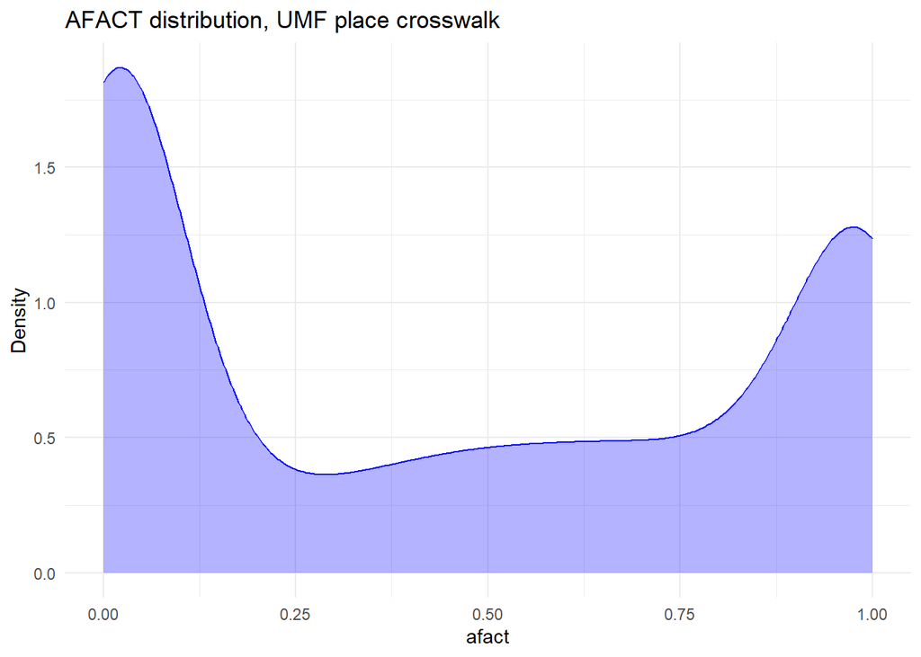

```r
puma_place_2021 %>%
  ggplot(aes(x = afact)) +
  geom_density(color = "blue", fill = alpha("blue", 0.3)) +
  theme_minimal() +
  ggtitle("AFACT distribution, UMF place crosswalk") +
  ylab("Density")
```

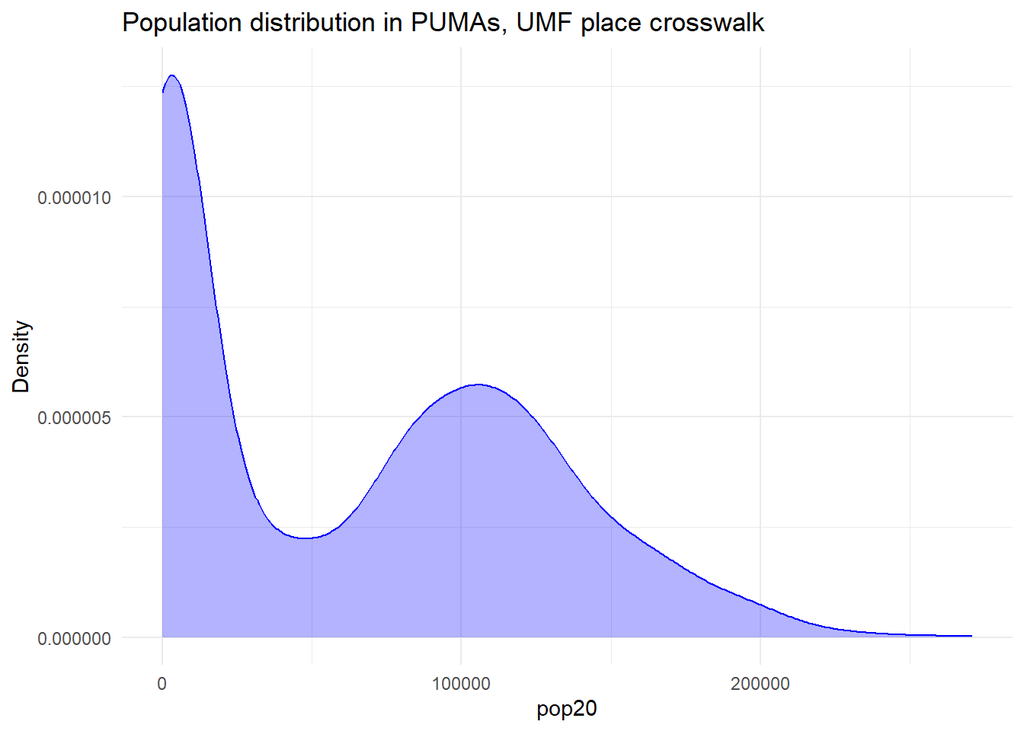

```r
puma_place_2021 %>%
  ggplot(aes(x = pop20)) +
  geom_density(color = "blue", fill = alpha("blue", 0.3)) +
  theme_minimal() +
  ggtitle("Population distribution in PUMAs, UMF place crosswalk") +
  ylab("Density")
```

Keep only the variables we will need

```r
puma_place_2021 <- puma_place_2021 %>%
  select(statefip, puma, place, pop20, afact, afact2)
```

Drop observations where the weight adjustment is zero.

```r
puma_place_2021 <- puma_place_2021 %>%
  filter(afact!= 0.000)
```

Create a variable that assigns a weight to each place based on the total 2020 population. First, create a variable for the total population.

```r
puma_place_2021 <- puma_place_2021 %>%
  mutate(totpop = sum(pop20))
```

Then, create a variable for the share of total population comprised by each place (unique state fip + county pairs)

```r
puma_place_2021 <- puma_place_2021 %>%
  group_by(statefip, place) %>%
  mutate(placepop = sum(pop20),
                placewgt = placepop/totpop)
```

Look at distribution of place total population shares (unique). NYC, LA and Chicago all hold disproportionate shares of the population.

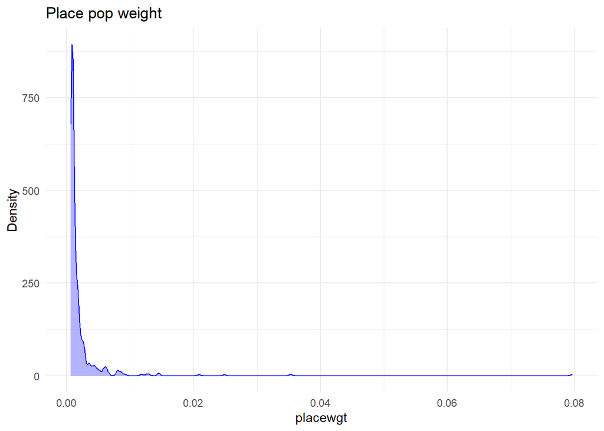

```r
puma_place_2021 %>%
  select(statefip, place, placewgt) %>%
  unique() %>%
  ggplot(aes(x = placewgt)) +
  geom_density(color = "blue", fill = alpha("blue", 0.3)) +
  theme_minimal() +
  ggtitle("Place pop weight") +
  ylab("Density")
```

### Create quality variable

Prepare for Data Quality flag (at end).

Create flags in the PUMA-place crosswalk for high percentage of data from outside of place. Per Greg (for counties), 75% or more from the county - in this case, place - is good, below 35% is bad, in between is marginal. This is calculated by taking the product of percentage of PUMA in place and percentage of place in PUMA for each place-PUMA pairing, and summing across the place.

```r
puma_place <- puma_place_2021 %>%
  mutate(products = afact*afact2)

puma_place <- puma_place %>%
  group_by(statefip, place) %>%
  mutate(sum_products = sum(products),
                place_pop = sum(pop20))
```

Sum_products mean is 0.76.

```r
puma_place %>%
  ungroup() %>%
  summarise(avg_sum_product = mean(sum_products))
```

```
# A tibble: 1 x 1
  avg_sum_product
            <dbl>
1           0.760
```

```r
puma_place <- puma_place %>%
  mutate(
    puma_flag =
      case_when(
        sum_products >= 0.75 ~ 1,
        sum_products >= 0.35 ~ 2,
        sum_products < 0.35 ~ 3
      ),
    small_place =
      case_when(
        placepop >= 110629 ~ 0,
        placepop < 110629 ~ 1
      )
  )
```

Save as “puma_place.csv” in the intermediate file.

```r
write_csv(puma_place, "data/intermediate/puma_place.csv")
```

Save a version with just the place-level values of data quality variables

```r
place_puma <- puma_place %>%
  group_by(statefip, place) %>%
  summarise(puma_flag = mean(puma_flag),
            small_place = mean(small_place))
```

Save as “place_puma.csv” in the intermediate file.

```r
write_csv(place_puma, "data/intermediate/place_puma.csv")
```

### Prepare microdata

First convert the IPUMS ACS missing values into NAs.

Missing data is reported in a variety of ways - listed below:

IPUMS says HHINCOME missing: 9999999 RENTGRS: No missing indicated OWNCOST: 99999 for not in universe

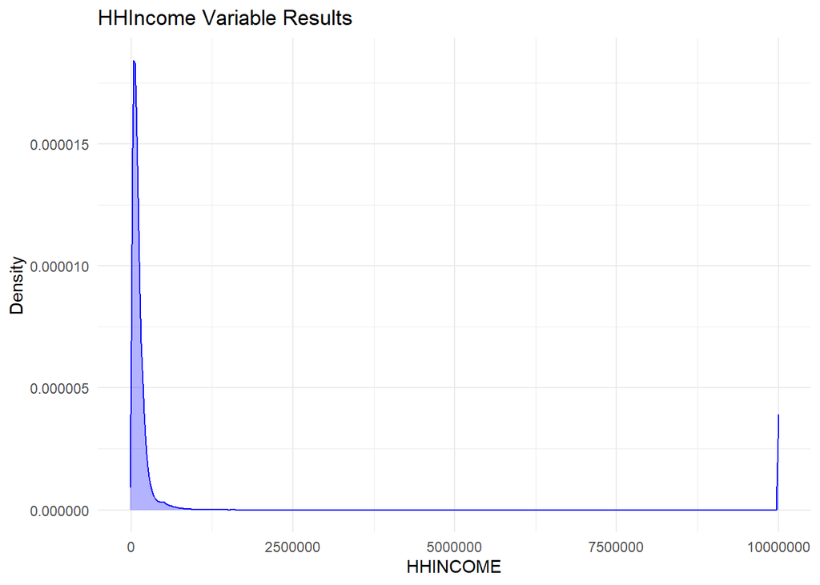

```r
acs_2021 %>%
  ggplot(aes(x = HHINCOME)) +
  geom_density(color = "blue", fill = alpha("blue", 0.3)) +
  theme_minimal() +
  ggtitle("HHIncome Variable Results") +
  ylab("Density")
```

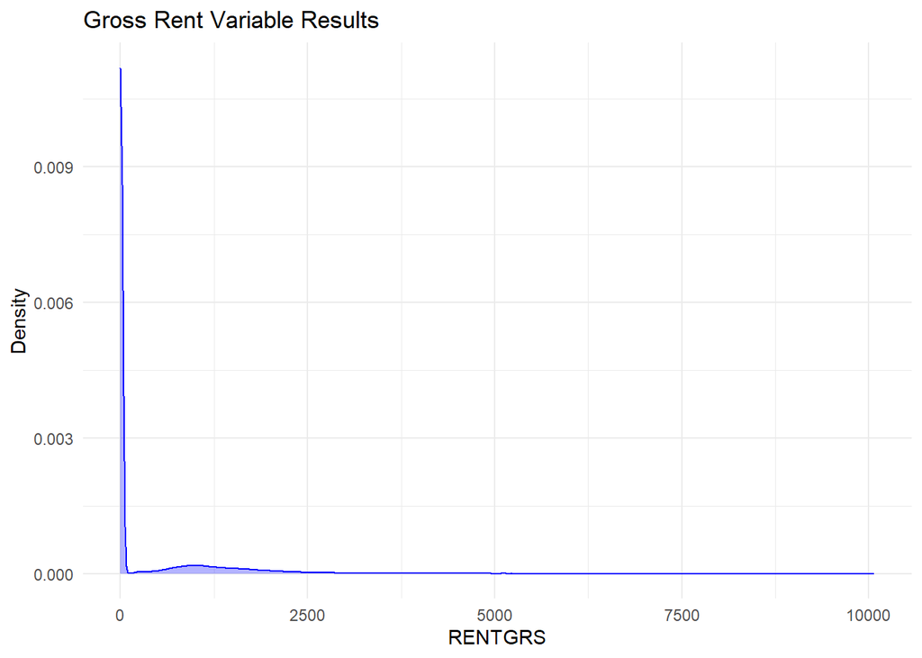

```r
acs_2021 %>%
  ggplot(aes(x = RENTGRS)) +
  geom_density(color = "blue", fill = alpha("blue", 0.3)) +
  theme_minimal() +
  ggtitle("Gross Rent Variable Results") +
  ylab("Density")
```

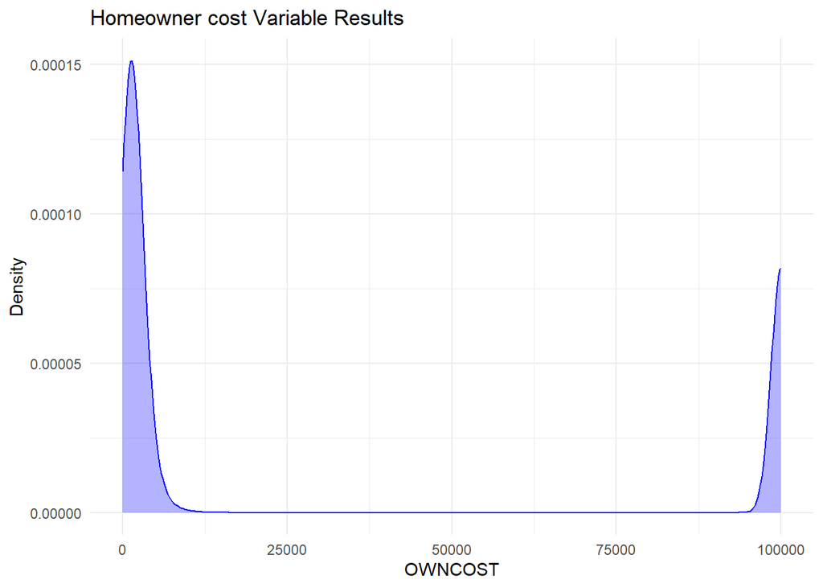

```r
acs_2021 %>%
  ggplot(aes(x = OWNCOST)) +
  geom_density(color = "blue", fill = alpha("blue", 0.3)) +
  theme_minimal() +
  ggtitle("Homeowner cost Variable Results") +
  ylab("Density")
```

Turn the missing/“not in universe” variable into NAs.

```r
acs2021clean <- acs_2021 %>%
  mutate(HHINCOME = ifelse(HHINCOME == 9999999, NA_integer_,
                          HHINCOME),
         OWNCOST = ifelse(OWNCOST == 99999, NA_integer_, OWNCOST)
  )
```

Look at distribution after adjustment (outliers should still exist but not comprise a signfianct share of the data).

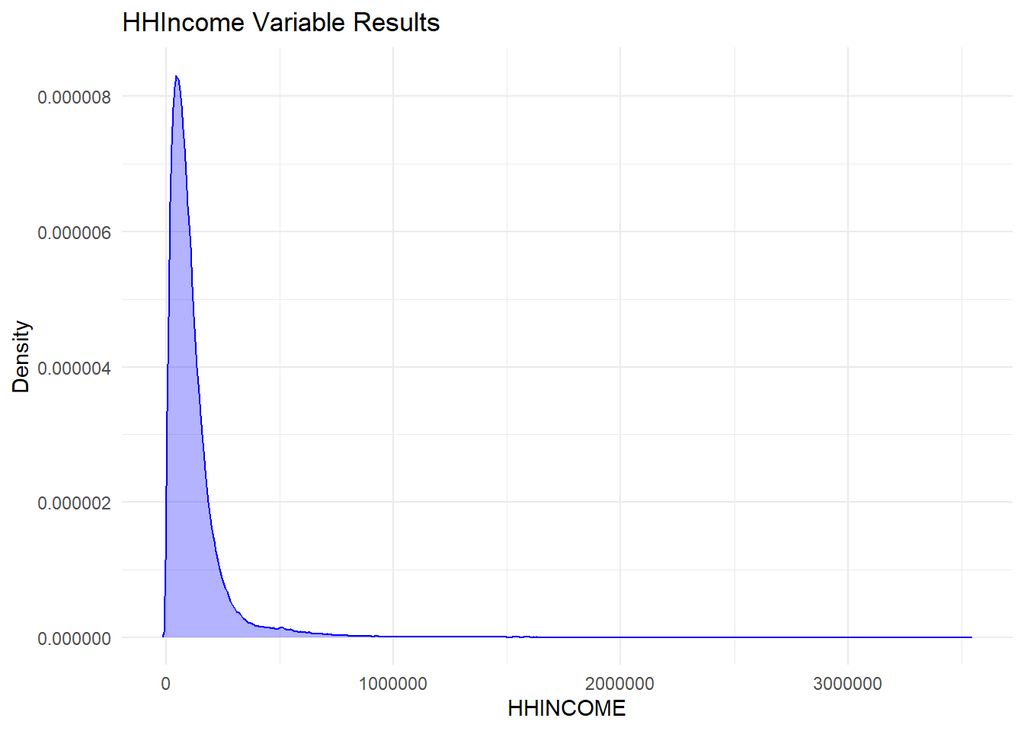

```r
acs2021clean %>%
  ggplot(aes(x = HHINCOME)) +
  geom_density(color = "blue", fill = alpha("blue", 0.3)) +
  theme_minimal() +
  ggtitle("HHIncome Variable Results") +
  ylab("Density")
```

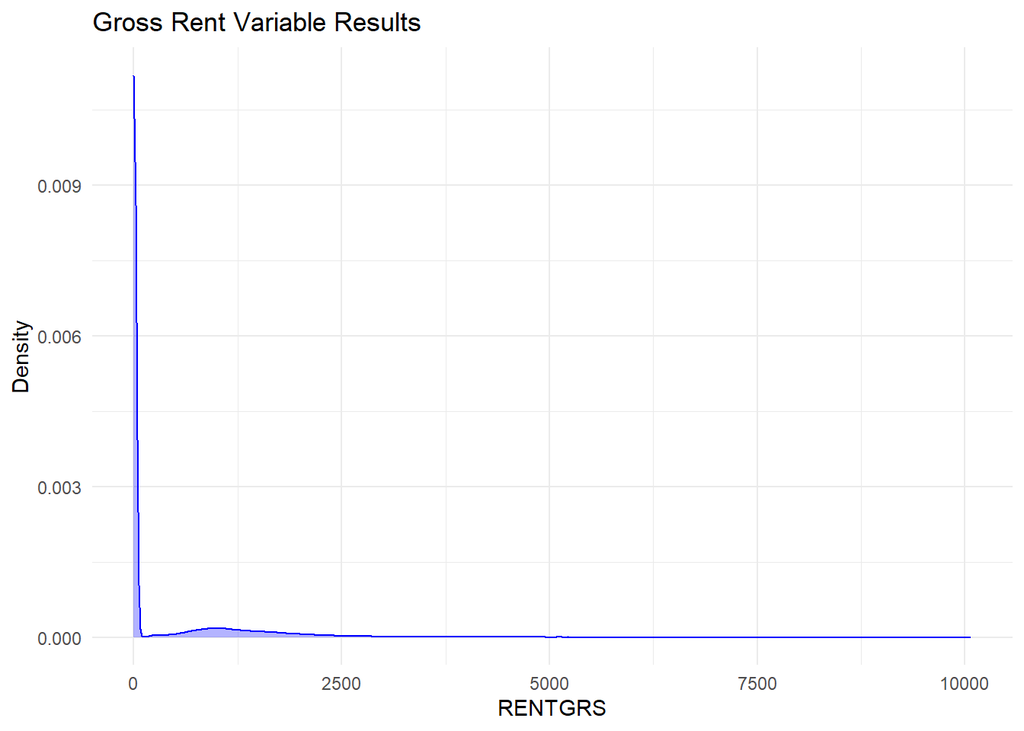

```r
acs2021clean %>%
  ggplot(aes(x = RENTGRS)) +
  geom_density(color = "blue", fill = alpha("blue", 0.3)) +
  theme_minimal() +
  ggtitle("Gross Rent Variable Results") +
  ylab("Density")
```

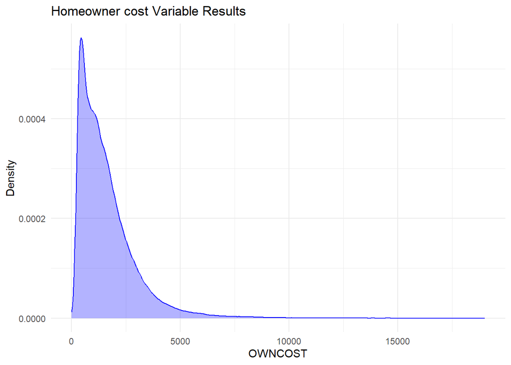

```r
acs2021clean %>%
  ggplot(aes(x = OWNCOST)) +
  geom_density(color = "blue", fill = alpha("blue", 0.3)) +
  theme_minimal() +
  ggtitle("Homeowner cost Variable Results") +
  ylab("Density")
```

```r
acs2021clean  <- left_join(acs2021clean, puma_place, by=c("statefip","puma"))
```

Run anti_join to see how many cases on the left did not have a match on the right

```r
test  <- anti_join(acs_2021, puma_place, by=c("statefip","puma"))
```

Drop any observations with NA for afact (i.e. there is no place of interest overlapping this PUMA).

```r
acs2021clean <- acs2021clean %>%
  filter(!is.na(afact))
```

Also filter out cases where AFACT is equal to zero.

```r
acs2021clean <- acs2021clean %>%
  filter(afact > 0)
```

Create a variable for the number of places per PUMA population per place (e.g., in unique statefip+place pairs).

```r
acs2021clean  <- acs2021clean  %>%
  group_by(puma, statefip) %>%
  mutate(places_per_PUMA = n_distinct(statefip, place))
```

Create a variable for the number of PUMAs per place.

```r
acs2021clean  <- acs2021clean %>%
  group_by(place, statefip) %>%
  mutate(PUMAs_per_place = n_distinct(statefip, puma))
```

Adjust weight to account for PUMA-to-county mapping (those where unique_types > 1).Drop PUMA flag variable from PUMA_place.

```r
acs2021clean <- acs2021clean %>%
  mutate(HHWT = HHWT*afact,
         HHINCOME = HHINCOME*ADJUST,
         PERWT = PERWT*afact,
         RENTGRS = RENTGRS*ADJUST,
         OWNCOST = OWNCOST*ADJUST
  ) %>%
  select(-puma_flag)
```

Remove group quarters.

```r
acs2021clean <- acs2021clean %>%
  filter(GQ < 3)
```

Create race/ethnicity variable.

Values for RACE variable: 1 White  
2 Black/African American/Negro  
3 American Indian or Alaska Native 4 Chinese 5 Japanese  
6 Other Asian or Pacific Islander 7 Other race, nec 8 Two major races 9 Three or more major races

Values for HISPAN variable: 0 Not Hispanic 1 Mexican 2 Puerto Rican· 3 Cuban 4 Other 9 Not Reported

```r
acs5yr_clean <- acs2021clean %>%
  mutate(subgroup = case_when((HISPAN == 0 & RACE == 1) ~ 4,
                              (HISPAN == 0 & RACE == 2) ~ 1,
                              (HISPAN == 0 & RACE %in% 3:9) ~ 3,
                              (HISPAN %in% 1:4) ~ 2,
  ))
```

Rename the values from number category to race label 4 = “White, Non-Hispanic” 1 = “Black, Non-Hispanic” 3 = “Other Races and Ethnicities” 2 = “Hispanic”

```r
acs5yr_clean <- acs5yr_clean %>%
  mutate(subgroup = case_when(subgroup %in% 1 ~ 'Black, Non-Hispanic',
                              subgroup %in% 2 ~ 'Hispanic',
                              subgroup %in% 3 ~ 'Other Races and Ethnicities',
                              subgroup %in% 4 ~ 'White, Non-Hispanic'
  ))
```

Save as “2021_5year_microdata.csv”

```r
write_csv(acs2021clean, "data/intermediate/2021_5year_microdata.csv")
```

Save a sub-group level place file to use as check/comparison for catching NA values.

```r
place_subgroup <- acs5yr_clean %>%
  group_by(statefip, place, subgroup) %>%
  summarise(
    n = n()
  )
```

Save as “place_subgroup.csv” in gitignore

```r
write_csv(place_subgroup, "data/intermediate/place_subgroup.csv")
```

## Create income percentiles variable

Objective: get pctl_20 pctl_50 and pctl_80 per unique state+place for subgroups in the year 2021 (from the 5-year data) for the var HHINCOME.

Aggregation should be weighted by HHWT

Isolate data to count each household only once (PERNUM == 1 counts head of household only).

```r
acs2021income <- acs5yr_clean %>%
  filter(PERNUM == 1)
```

Remove records where HHINCOME is missing - NA.

```r
acs2021income <- acs2021income %>%
  filter(!is.na(HHINCOME))
```

Calculate quantiles by grouping variable place.

```r
metrics_income <- acs2021income %>%
  group_by(statefip, place, subgroup) %>%
  summarise(pctl_20 = Hmisc::wtd.quantile(HHINCOME, weights = HHWT, probs = 0.2),
                   pctl_50 = Hmisc::wtd.quantile(HHINCOME, weights = HHWT, probs = 0.5),
                   pctl_80 = Hmisc::wtd.quantile(HHINCOME, weights = HHWT, probs = 0.8),
                   count = n())
```

### Finish the Data Quality variable

For Income metric: total number of households is the sample size we are checking.

```r
metrics_income <- metrics_income %>%
  mutate(size_flag = case_when((count < 30) ~ 1,
                               (count >= 30) ~ 0))
```

Merge the PUMA flag in & create the final data quality metric based on both size and puma flags

```r
metrics_income <- left_join(metrics_income, place_puma, by=c("statefip","place"))
```

Generate the quality var

```r
metrics_income <- metrics_income %>%
  mutate(pctl_20_quality = case_when(size_flag==0 & puma_flag==1 ~ 1,
                                     size_flag==0 & puma_flag==2 ~ 2,
                                     size_flag==0 & puma_flag==3 ~ 3,
                                     size_flag==1 ~ 3),
         pctl_50_quality = case_when(size_flag==0 & puma_flag==1 ~ 1,
                                     size_flag==0 & puma_flag==2 ~ 2,
                                     size_flag==0 & puma_flag==3 ~ 3,
                                     size_flag==1 ~ 3),
         pctl_80_quality = case_when(size_flag==0 & puma_flag==1 ~ 1,
                                     size_flag==0 & puma_flag==2 ~ 2,
                                     size_flag==0 & puma_flag==3 ~ 3,
                                     size_flag==1 ~ 3)
  )
```

### Evaluate results

Look at distributions of income percentiles by place.

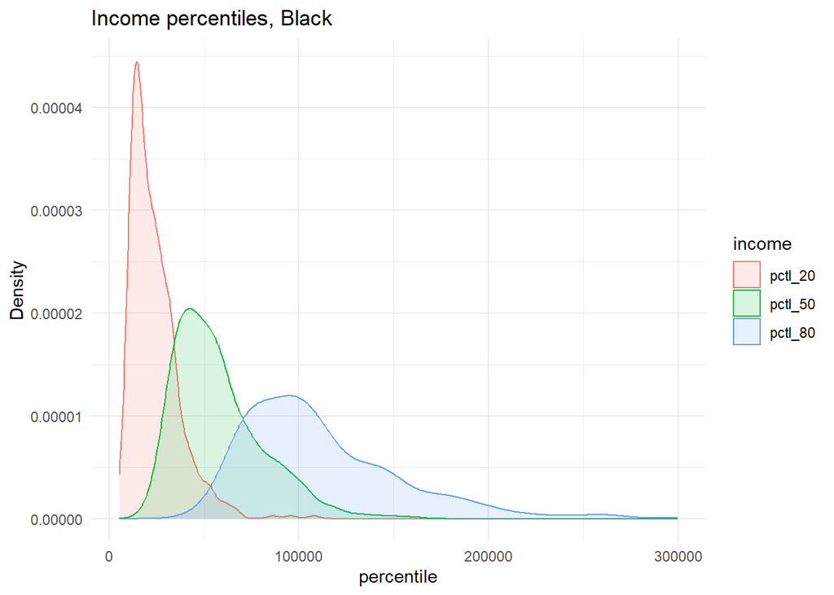

```r
metrics_income %>%
  ungroup() %>%
  filter(subgroup == "Black, Non-Hispanic") %>%
  select(place, pctl_20, pctl_50, pctl_80) %>%
  pivot_longer(cols = c(pctl_20, pctl_50, pctl_80), names_to = "income", values_to = "percentile") %>%
  ggplot(aes(x = percentile, color = income, fill = income)) +
  geom_density(alpha = 0.15) +
  theme_minimal() +
  ggtitle("Income percentiles, Black") +
  ylab("Density")
```

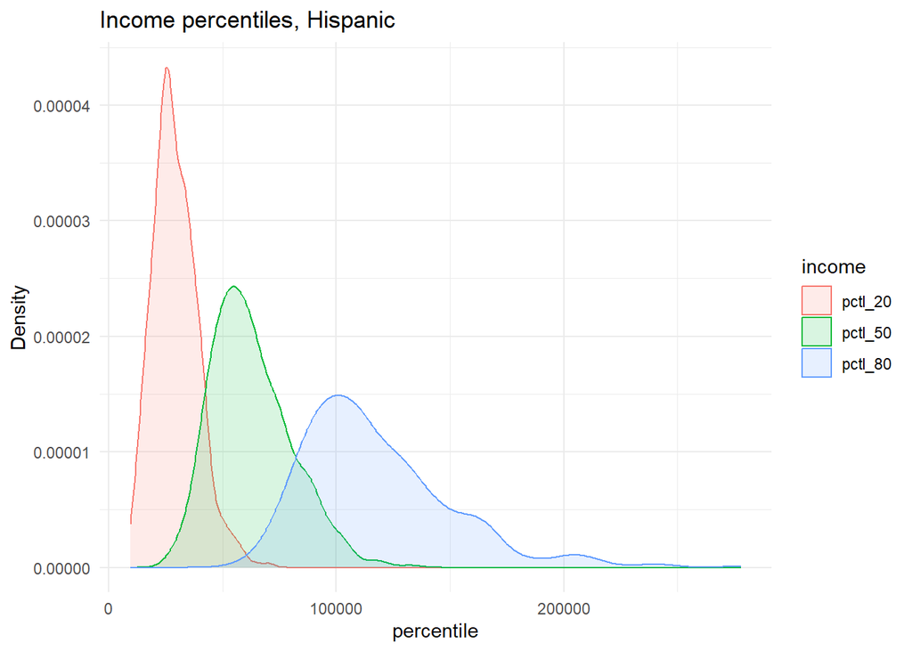

```r
  metrics_income %>%
  ungroup() %>%
  filter(subgroup == "Hispanic") %>%
  select(place, pctl_20, pctl_50, pctl_80) %>%
  pivot_longer(cols = c(pctl_20, pctl_50, pctl_80), names_to = "income", values_to = "percentile") %>%
  ggplot(aes(x = percentile, color = income, fill = income)) +
  geom_density(alpha = 0.15) +
  theme_minimal() +
  ggtitle("Income percentiles, Hispanic") +
  ylab("Density")
```

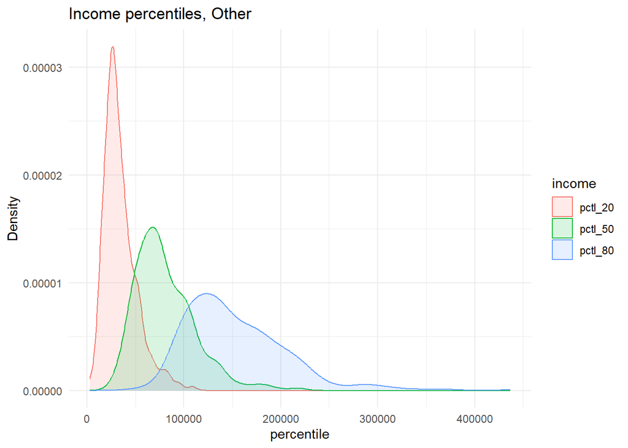

```r
metrics_income %>%
  ungroup() %>%
  filter(subgroup == "Other Races and Ethnicities")  %>%
  select(place, pctl_20, pctl_50, pctl_80) %>%
  pivot_longer(cols = c(pctl_20, pctl_50, pctl_80), names_to = "income", values_to = "percentile") %>%
  ggplot(aes(x = percentile, color = income, fill = income)) +
  geom_density(alpha = 0.15) +
  theme_minimal() +
  ggtitle("Income percentiles, Other") +
  ylab("Density")
```

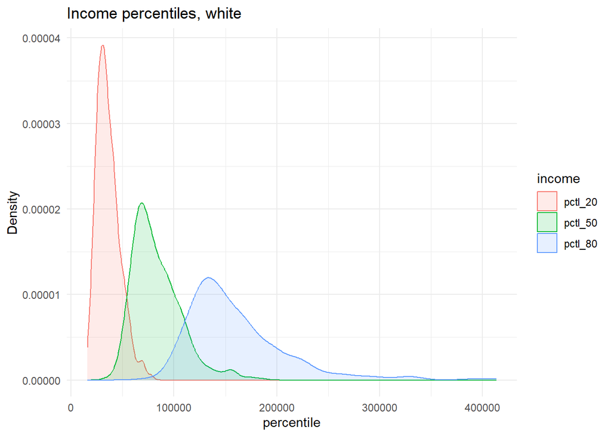

```r
metrics_income %>%
  ungroup() %>%
  filter(subgroup == "White, Non-Hispanic")  %>%
  select(place, pctl_20, pctl_50, pctl_80) %>%
  pivot_longer(cols = c(pctl_20, pctl_50, pctl_80), names_to = "income", values_to = "percentile") %>%
  ggplot(aes(x = percentile, color = income, fill = income)) +
  geom_density(alpha = 0.15) +
  theme_minimal() +
  ggtitle("Income percentiles, white") +
  ylab("Density")
```

## Export

Rename state.

```r
metrics_income <- metrics_income %>%
  rename('state' = 'statefip')
```

Add a variable for the year of the data

```r
metrics_income <- metrics_income %>%
  mutate(
    year = 2021
  )
```

Order the variables how we want

```r
metrics_income <- metrics_income %>%
  select(year, state, place, subgroup, pctl_20, pctl_20_quality, pctl_50,
         pctl_50_quality, pctl_80, pctl_80_quality)
```

### Add on all variable

Read in the income percentile variable for all households in the place.

```r
income_all <- read_csv("data/final/metrics_income_city_2021.csv")

income_all <- income_all %>%
  mutate(
    subgroup = "All"
  )
```

Append the “All” version of the data

```r
metrics_income <- bind_rows(metrics_income, income_all)
```

Sort by place again to double check we have 5 observations per place (All, Black, White, Hispanic, Other)

```r
metrics_income <- metrics_income %>%
  arrange(state, place)
```

### Export as CSV

Export file as CSV.

```r
write_csv(metrics_income, "data/final/metrics_income_city_subgroup_2021.csv")
```

## Compare with counties

Compare results from places that share boundaries with counties against the results of those counties. These should be the same.

First read in the fips information for these places.

```r
independent_cities <- read_csv("data/raw/independent_cities.csv") %>%
    mutate(state = sprintf("%0.2d", as.numeric(state)),
         county = sprintf("%0.3d", as.numeric(county)),
         place = sprintf("%0.5d", as.numeric(place))) %>%
  mutate(state = as.character(state))
```

Net read in the final place and county data.

```r
metrics_income_place <- read_csv("data/final/metrics_income_city_subgroup_2021.csv") %>%
  left_join(independent_cities, by = c("state" = "state", "place" = "place")) %>%
  filter(!is.na(county))
```

Read in county and select just needed variables.

```r
metrics_income_county <- read_csv("data/final/metrics_income_subgroup_county_2021.csv") %>%
  select(state, county, subgroup, pctl_20_county = pctl_20,
         pctl_50_county = pctl_50,
         pctl_80_county = pctl_80
         )
```

Join onto place data and calculate difference between income metrics. No difference.

```r
metrics_income_place %>%
  left_join(metrics_income_county, by = c("state" = "state", "county" = "county", "subgroup" = "subgroup")) %>%
  mutate(diff_20 = pctl_20 - pctl_20_county,
         diff_50 = pctl_50 - pctl_50_county,
         diff_80 = pctl_80 - pctl_80_county) %>%
  select(state, place, county, subgroup, diff_20, diff_50, diff_80) %>%
  reactable(

  )
```

| state | place | county | subgroup | diff_20 | diff_50 | diff_80 |
| --- | --- | --- | --- | --- | --- | --- |
| 24 | 04000 | 510 | Black, Non-Hispanic | 0 | 0 | 0 |
| 24 | 04000 | 510 | Hispanic | 0 | 0 | 0 |
| 24 | 04000 | 510 | Other Races and Ethnicities | 0 | 0 | 0 |
| 24 | 04000 | 510 | White, Non-Hispanic | 0 | 0 | 0 |
| 24 | 04000 | 510 | All | 0 | 0 | 0 |
| 29 | 65000 | 510 | Black, Non-Hispanic | 0 | 0 | 0 |
| 29 | 65000 | 510 | Hispanic | 0 | 0 | 0 |
| 29 | 65000 | 510 | Other Races and Ethnicities | 0 | 0 | 0 |
| 29 | 65000 | 510 | White, Non-Hispanic | 0 | 0 | 0 |
| 29 | 65000 | 510 | All | 0 | 0 | 0 |

[output cut: 55 more lines]